# IE360_HW1

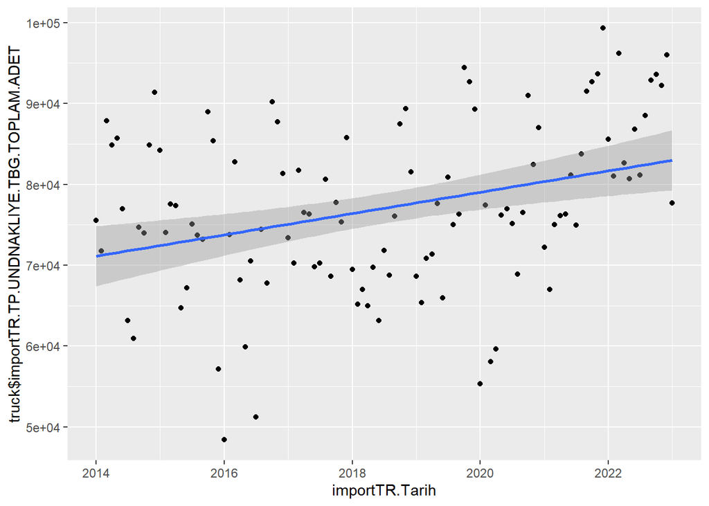

```r
ggplot(truck ,aes(x=importTR.Tarih,y=truck$importTR.TP.UNDNAKLIYE.TBG.TOPLAM.ADET)) + geom_point() +geom_smooth(method='lm')
```

Since we see seasonality and trend effects we instating dummy seasonality variables to our all data sets. These are: Trnd which is time change from start to end of the data month which is month of the individual data since lag 12 autocorelation exists it will be significant

```r
productivity <- as.data.table(productivity)
productivity[,trnd:=1:.N]
productivity[,mon:=as.character(month(importTR.Tarih,label=T))]
head(productivity)
```

```
##    importTR.Tarih importTR.TP.KKO.MA importTR.Uretim importTR.TP.KTF17
##            <Date>              <num>           <int>             <num>
## 1:     2014-01-01               76.1              20           13.2480
## 2:     2014-02-01               74.9              19           15.4500
## 3:     2014-03-01               75.9              19           16.0625
## 4:     2014-04-01               75.6              21           15.0625
## 5:     2014-05-01               74.9              19           14.1520
## 6:     2014-06-01               75.2              18           13.5025
##    importTR.TP.TSANAYMT2021.Y1  trnd    mon
##                          <num> <int> <char>
## 1:                    69.95363     1    Oca
## 2:                    69.35886     2    Şub
## 3:                    69.44829     3    Mar
## 4:                    68.84842     4    Nis
## 5:                    67.90698     5    May
## 6:                    69.28235     6    Haz
```

```r
workforce <- as.data.table(workforce)
workforce[,trnd:=1:.N]
workforce[,mon:=as.character(month(importTR.Tarih,label=T))]
head(workforce)
```

```
##    importTR.Tarih importTR.TP.TIG03 importTR.Turk.Is.Kurumu
##            <Date>             <num>                   <int>
## 1:     2014-01-01             25434                      31
## 2:     2014-02-01             25357                      32
## 3:     2014-03-01             25771                      30
## 4:     2014-04-01             25758                      30
## 5:     2014-05-01             25663                      31
## 6:     2014-06-01             26098                      29
##    importTR.TP.AC2.TOP.A importTR.TP.KAP2.TOP.A  trnd    mon
##                    <num>                  <num> <int> <char>
## 1:                  5916                   2892     1    Oca
## 2:                  4771                   1181     2    Şub
## 3:                  5026                   1073     3    Mar
## 4:                  4959                    937     4    Nis
## 5:                  4768                    968     5    May
## 6:                  4851                   1120     6    Haz
```

```r
truck <- as.data.table(truck)
truck[,trnd:=1:.N]
truck[,mon:=as.character(month(importTR.Tarih,label=T))]
head(truck)
```

```
##    importTR.Tarih importTR.TP.UNDNAKLIYE.TBG.TOPLAM.ADET
##            <Date>                                  <num>
## 1:     2014-01-01                                  75532
## 2:     2014-02-01                                  71733
## 3:     2014-03-01                                  87857
## 4:     2014-04-01                                  84838
## 5:     2014-05-01                                  85717
## 6:     2014-06-01                                  76983
##    importTR.Kapikule.Sinir.Kapisi importTR.TP.TSANAYMT2021.Y1
##                             <int>                       <num>
## 1:                              2                    69.95363
## 2:                              5                    69.35886
## 3:                              3                    69.44829
## 4:                              3                    68.84842
## 5:                              2                    67.90698
## 6:                              2                    69.28235
##    importTR.TP.DK.USD.A.YTL  trnd    mon
##                       <num> <int> <char>
## 1:                 2.216836     1    Oca
## 2:                 2.212760     2    Şub
## 3:                 2.217795     3    Mar
## 4:                 2.127471     4    Nis
## 5:                 2.090805     5    May
## 6:                 2.115724     6    Haz
```

From there we are checking trends of each month. This shows that how the seasonality is effective.

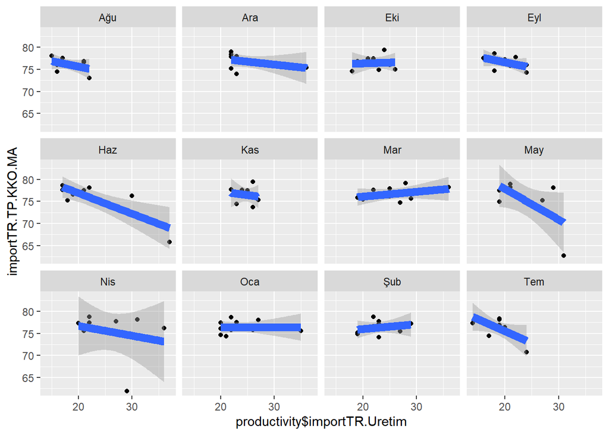

```r
ggplot(productivity,aes(x=productivity$importTR.Uretim,y=importTR.TP.KKO.MA)) +
        geom_point() + geom_smooth(method=lm,linewidth=3) + facet_wrap(~mon)
```